# City Bike Share

## Introduction

Aim: The aim of this analysis is to provide insight on the data and to suggest approaches to optimize bike placement and reallocation schedule for the operator by considering usage patterns during the day and week, weather and ride-distances.

Input data:

- station.csv - Contains data that represents a station where users can pickup or return bikes.
- status.csv - data about the number of bikes and docks available for given station and minute.
- trips.csv - Data about individual bike trips
- weather.csv - Data about the weather on a specific day for certain zip codes

Assumptions:

- when choosing to take a trip, passengers would base their decision to cycle on the weather that day i.e. the start_date of the trip
- in Weather csv, 'T' in precipitation Inches denotes trace percipitation and can be represented as 0
- In Weather.csv event field, a null value indicates no event.
- Commuter volume drops on public holidays.

```python
import os
import re
import pandas as pd
import numpy as np
import dabl
import random
import geopy
import shap
import matplotlib.pyplot as plt
import seaborn as sns
pd.set_option('display.max_columns',500)
pd.set_option('display.max_columns', 500)
pd.set_option('display.width', 10000)
plt.rcParams['figure.figsize'] = [18, 6]
plt.rcParams['figure.dpi'] = 100 # 200 e.g. is really fine, but slower
```

## Helper Functions

```python
def check_null_values(df):
    ''' Missing values'''
    null_df = pd.DataFrame({'columns': df.columns,
                            'percent_null': df.isnull().sum() * 100 / len(df),
                           'percent_zero': df.isin([0]).sum() * 100 / len(df)
                           } )
    return null_df


def count_unique_values(df, categorical_features):
    ''' Cardinality of the categorical variables'''

    cat_df = df[categorical_features]
    val_df = pd.DataFrame({'columns': cat_df.columns,
                       'cardinality': cat_df.nunique() } )
    return val_df
```

## Read In Data

```python
DATA_PATH = '/Users/loconno8/Projects/SFBayAreaBikeShare/data/'
OUT_PATH = '/Users/loconno8/Projects/SFBayAreaBikeShare/'
```

```python
os.listdir(DATA_PATH)
```

```
['database.sqlite', 'station.csv', 'status.csv', 'trip.csv', 'weather.csv']
```

```python
%%time
station_df = pd.read_csv(os.path.join(DATA_PATH, 'station.csv'))
status_df = pd.read_csv(os.path.join(DATA_PATH, 'status.csv'))
trip_df = pd.read_csv(os.path.join(DATA_PATH, 'trip.csv'))
weather_df = pd.read_csv(os.path.join(DATA_PATH, 'weather.csv'))
```

```
CPU times: user 47.9 s, sys: 22.5 s, total: 1min 10s
Wall time: 1min 9s
```

```python
print(f'station_df shape is: {station_df.shape}')
print(f'status_df shape is: {status_df.shape}')
print(f'trip_df shape is: {trip_df.shape}')
print(f'weather_df shape is: {weather_df.shape}')
```

```
station_df shape is: (70, 7)
status_df shape is: (71984434, 4)
trip_df shape is: (669959, 11)
weather_df shape is: (3665, 24)
```

```python
station_df.head()
```

|  | id | name | lat | long | dock_count | city | installation_date |
| --- | --- | --- | --- | --- | --- | --- | --- |
| 0 | 2 | San Jose Diridon Caltrain Station | 37.329732 | -121.901782 | 27 | San Jose | 8/6/2013 |
| 1 | 3 | San Jose Civic Center | 37.330698 | -121.888979 | 15 | San Jose | 8/5/2013 |
| 2 | 4 | Santa Clara at Almaden | 37.333988 | -121.894902 | 11 | San Jose | 8/6/2013 |
| 3 | 5 | Adobe on Almaden | 37.331415 | -121.893200 | 19 | San Jose | 8/5/2013 |
| 4 | 6 | San Pedro Square | 37.336721 | -121.894074 | 15 | San Jose | 8/7/2013 |

```python
station_df.describe().T
```

|  | count | mean | std | min | 25% | 50% | 75% | max |
| --- | --- | --- | --- | --- | --- | --- | --- | --- |
| id | 70.0 | 43.000000 | 24.166092 | 2.000000 | 24.250000 | 43.500000 | 63.750000 | 84.000000 |
| lat | 70.0 | 37.590243 | 0.203473 | 37.329732 | 37.389483 | 37.631163 | 37.788123 | 37.804770 |
| long | 70.0 | -122.218416 | 0.209446 | -122.418954 | -122.400601 | -122.312123 | -122.078009 | -121.877349 |
| dock_count | 70.0 | 17.657143 | 4.010442 | 11.000000 | 15.000000 | 15.000000 | 19.000000 | 27.000000 |

```python
trip_df.head()
```

|  | id | duration | start_date | start_station_name | start_station_id | end_date | end_station_name | end_station_id | bike_id | subscription_type | zip_code |
| --- | --- | --- | --- | --- | --- | --- | --- | --- | --- | --- | --- |
| 0 | 4576 | 63 | 8/29/2013 14:13 | South Van Ness at Market | 66 | 8/29/2013 14:14 | South Van Ness at Market | 66 | 520 | Subscriber | 94127 |
| 1 | 4607 | 70 | 8/29/2013 14:42 | San Jose City Hall | 10 | 8/29/2013 14:43 | San Jose City Hall | 10 | 661 | Subscriber | 95138 |
| 2 | 4130 | 71 | 8/29/2013 10:16 | Mountain View City Hall | 27 | 8/29/2013 10:17 | Mountain View City Hall | 27 | 48 | Subscriber | 97214 |
| 3 | 4251 | 77 | 8/29/2013 11:29 | San Jose City Hall | 10 | 8/29/2013 11:30 | San Jose City Hall | 10 | 26 | Subscriber | 95060 |
| 4 | 4299 | 83 | 8/29/2013 12:02 | South Van Ness at Market | 66 | 8/29/2013 12:04 | Market at 10th | 67 | 319 | Subscriber | 94103 |

```python
trip_df.describe().T
```

|  | count | mean | std | min | 25% | 50% | 75% | max |
| --- | --- | --- | --- | --- | --- | --- | --- | --- |
| id | 669959.0 | 460382.009899 | 264584.458487 | 4069.0 | 231082.5 | 459274.0 | 692601.0 | 913460.0 |
| duration | 669959.0 | 1107.949846 | 22255.437020 | 60.0 | 344.0 | 517.0 | 755.0 | 17270400.0 |
| start_station_id | 669959.0 | 57.851876 | 17.112474 | 2.0 | 50.0 | 62.0 | 70.0 | 84.0 |
| end_station_id | 669959.0 | 57.837438 | 17.200142 | 2.0 | 50.0 | 62.0 | 70.0 | 84.0 |
| bike_id | 669959.0 | 427.587620 | 153.450988 | 9.0 | 334.0 | 440.0 | 546.0 | 878.0 |

```python
weather_df.head()
```

|  | date | max_temperature_f | mean_temperature_f | min_temperature_f | max_dew_point_f | mean_dew_point_f | min_dew_point_f | max_humidity | mean_humidity | min_humidity | max_sea_level_pressure_inches | mean_sea_level_pressure_inches | min_sea_level_pressure_inches | max_visibility_miles | mean_visibility_miles | min_visibility_miles | max_wind_Speed_mph | mean_wind_speed_mph | max_gust_speed_mph | precipitation_inches | cloud_cover | events | wind_dir_degrees | zip_code |
| --- | --- | --- | --- | --- | --- | --- | --- | --- | --- | --- | --- | --- | --- | --- | --- | --- | --- | --- | --- | --- | --- | --- | --- | --- |
| 0 | 8/29/2013 | 74.0 | 68.0 | 61.0 | 61.0 | 58.0 | 56.0 | 93.0 | 75.0 | 57.0 | 30.07 | 30.02 | 29.97 | 10.0 | 10.0 | 10.0 | 23.0 | 11.0 | 28.0 | 0 | 4.0 | NaN | 286.0 | 94107 |
| 1 | 8/30/2013 | 78.0 | 69.0 | 60.0 | 61.0 | 58.0 | 56.0 | 90.0 | 70.0 | 50.0 | 30.05 | 30.00 | 29.93 | 10.0 | 10.0 | 7.0 | 29.0 | 13.0 | 35.0 | 0 | 2.0 | NaN | 291.0 | 94107 |
| 2 | 8/31/2013 | 71.0 | 64.0 | 57.0 | 57.0 | 56.0 | 54.0 | 93.0 | 75.0 | 57.0 | 30.00 | 29.96 | 29.92 | 10.0 | 10.0 | 10.0 | 26.0 | 15.0 | 31.0 | 0 | 4.0 | NaN | 284.0 | 94107 |
| 3 | 9/1/2013 | 74.0 | 66.0 | 58.0 | 60.0 | 56.0 | 53.0 | 87.0 | 68.0 | 49.0 | 29.96 | 29.93 | 29.91 | 10.0 | 10.0 | 10.0 | 25.0 | 13.0 | 29.0 | 0 | 4.0 | NaN | 284.0 | 94107 |
| 4 | 9/2/2013 | 75.0 | 69.0 | 62.0 | 61.0 | 60.0 | 58.0 | 93.0 | 77.0 | 61.0 | 29.97 | 29.94 | 29.90 | 10.0 | 10.0 | 6.0 | 23.0 | 12.0 | 30.0 | 0 | 6.0 | NaN | 277.0 | 94107 |

```python
weather_df.describe().T
```

|  | count | mean | std | min | 25% | 50% | 75% | max |
| --- | --- | --- | --- | --- | --- | --- | --- | --- |
| max_temperature_f | 3661.0 | 70.580989 | 8.385572 | 44.00 | 64.00 | 70.00 | 77.00 | 102.00 |
| mean_temperature_f | 3661.0 | 61.348812 | 7.234397 | 38.00 | 56.00 | 61.00 | 67.00 | 84.00 |
| min_temperature_f | 3661.0 | 51.947282 | 7.441444 | 25.00 | 47.00 | 53.00 | 58.00 | 75.00 |
| max_dew_point_f | 3611.0 | 53.149820 | 6.885449 | 20.00 | 49.00 | 54.00 | 58.00 | 68.00 |
| mean_dew_point_f | 3611.0 | 48.794794 | 7.822281 | 13.00 | 44.00 | 49.00 | 55.00 | 65.00 |
| min_dew_point_f | 3611.0 | 44.306840 | 9.355432 | 2.00 | 39.00 | 46.00 | 52.00 | 63.00 |
| max_humidity | 3611.0 | 85.446968 | 9.226972 | 24.00 | 82.00 | 86.00 | 93.00 | 100.00 |
| mean_humidity | 3611.0 | 67.256993 | 10.945591 | 24.00 | 62.00 | 68.00 | 74.00 | 96.00 |
| min_humidity | 3611.0 | 46.458045 | 14.434784 | 4.00 | 37.00 | 48.00 | 56.00 | 93.00 |
| max_sea_level_pressure_inches | 3664.0 | 30.074997 | 0.134492 | 29.50 | 29.98 | 30.06 | 30.17 | 30.65 |
| mean_sea_level_pressure_inches | 3664.0 | 30.022290 | 0.130795 | 29.43 | 29.93 | 30.01 | 30.11 | 30.41 |
| min_sea_level_pressure_inches | 3664.0 | 29.965835 | 0.133476 | 28.98 | 29.88 | 29.95 | 30.05 | 30.37 |
| max_visibility_miles | 3652.0 | 10.555312 | 2.193828 | 5.00 | 10.00 | 10.00 | 10.00 | 20.00 |
| mean_visibility_miles | 3652.0 | 9.822015 | 1.469894 | 4.00 | 10.00 | 10.00 | 10.00 | 20.00 |
| min_visibility_miles | 3652.0 | 8.229737 | 2.862132 | 0.00 | 7.00 | 10.00 | 10.00 | 20.00 |
| max_wind_Speed_mph | 3664.0 | 16.398472 | 7.787588 | 0.00 | 13.00 | 16.00 | 20.00 | 128.00 |
| mean_wind_speed_mph | 3664.0 | 5.962063 | 3.340603 | 0.00 | 3.00 | 6.00 | 8.00 | 23.00 |
| max_gust_speed_mph | 2766.0 | 22.299349 | 9.618813 | 6.00 | 17.00 | 22.00 | 25.00 | 114.00 |
| cloud_cover | 3664.0 | 2.784389 | 2.276401 | 0.00 | 1.00 | 3.00 | 5.00 | 8.00 |
| wind_dir_degrees | 3664.0 | 266.605895 | 102.047645 | 0.00 | 254.00 | 297.00 | 330.00 | 2772.00 |
| zip_code | 3665.0 | 94325.000000 | 404.615212 | 94041.00 | 94063.00 | 94107.00 | 94301.00 | 95113.00 |

## Exploratory Data Analysis

```python
null_df = check_null_values(weather_df)
null_df.sort_values('percent_null', ascending=False)[0:50]
```

|  | columns | percent_null | percent_zero |
| --- | --- | --- | --- |
| events | events | 85.757162 | 0.000000 |
| max_gust_speed_mph | max_gust_speed_mph | 24.529332 | 0.000000 |
| max_dew_point_f | max_dew_point_f | 1.473397 | 0.000000 |
| mean_dew_point_f | mean_dew_point_f | 1.473397 | 0.000000 |
| min_dew_point_f | min_dew_point_f | 1.473397 | 0.000000 |
| max_humidity | max_humidity | 1.473397 | 0.000000 |
| min_humidity | min_humidity | 1.473397 | 0.000000 |
| mean_humidity | mean_humidity | 1.473397 | 0.000000 |
| max_visibility_miles | max_visibility_miles | 0.354707 | 0.000000 |
| mean_visibility_miles | mean_visibility_miles | 0.354707 | 0.000000 |
| min_visibility_miles | min_visibility_miles | 0.354707 | 2.537517 |
| mean_temperature_f | mean_temperature_f | 0.109141 | 0.000000 |
| min_temperature_f | min_temperature_f | 0.109141 | 0.000000 |
| max_temperature_f | max_temperature_f | 0.109141 | 0.000000 |
| mean_wind_speed_mph | mean_wind_speed_mph | 0.027285 | 1.036835 |
| cloud_cover | cloud_cover | 0.027285 | 22.755798 |
| precipitation_inches | precipitation_inches | 0.027285 | 0.000000 |
| min_sea_level_pressure_inches | min_sea_level_pressure_inches | 0.027285 | 0.000000 |
| max_wind_Speed_mph | max_wind_Speed_mph | 0.027285 | 0.027285 |
| wind_dir_degrees | wind_dir_degrees | 0.027285 | 0.027285 |
| max_sea_level_pressure_inches | max_sea_level_pressure_inches | 0.027285 | 0.000000 |
| mean_sea_level_pressure_inches | mean_sea_level_pressure_inches | 0.027285 | 0.000000 |
| date | date | 0.000000 | 0.000000 |
| zip_code | zip_code | 0.000000 | 0.000000 |

```python
# Interpreting a null value in the events field as no event
weather_df.events = weather_df.events.fillna('No Event')
```

```python
null_df = check_null_values(trip_df)
null_df.sort_values('percent_null', ascending=False)[0:50]
```

|  | columns | percent_null | percent_zero |
| --- | --- | --- | --- |
| zip_code | zip_code | 0.987971 | 0.0 |
| id | id | 0.000000 | 0.0 |
| duration | duration | 0.000000 | 0.0 |
| start_date | start_date | 0.000000 | 0.0 |
| start_station_name | start_station_name | 0.000000 | 0.0 |
| start_station_id | start_station_id | 0.000000 | 0.0 |
| end_date | end_date | 0.000000 | 0.0 |
| end_station_name | end_station_name | 0.000000 | 0.0 |
| end_station_id | end_station_id | 0.000000 | 0.0 |
| bike_id | bike_id | 0.000000 | 0.0 |
| subscription_type | subscription_type | 0.000000 | 0.0 |

```python
null_df = check_null_values(status_df)
null_df.sort_values('percent_null', ascending=False)[0:50]
```

|  | columns | percent_null | percent_zero |
| --- | --- | --- | --- |
| station_id | station_id | 0.0 | 0.000000 |
| bikes_available | bikes_available | 0.0 | 0.734887 |
| docks_available | docks_available | 0.0 | 0.453819 |
| time | time | 0.0 | 0.000000 |

```python
null_df = check_null_values(station_df)
null_df.sort_values('percent_null', ascending=False)[0:50]
```

|  | columns | percent_null | percent_zero |
| --- | --- | --- | --- |
| id | id | 0.0 | 0.0 |
| name | name | 0.0 | 0.0 |
| lat | lat | 0.0 | 0.0 |
| long | long | 0.0 | 0.0 |
| dock_count | dock_count | 0.0 | 0.0 |
| city | city | 0.0 | 0.0 |
| installation_date | installation_date | 0.0 | 0.0 |

### Station locations

```python
print("Check number of different stations: {}".format(status_df.station_id.nunique()))
```

```
Check number of different stations: 70
```

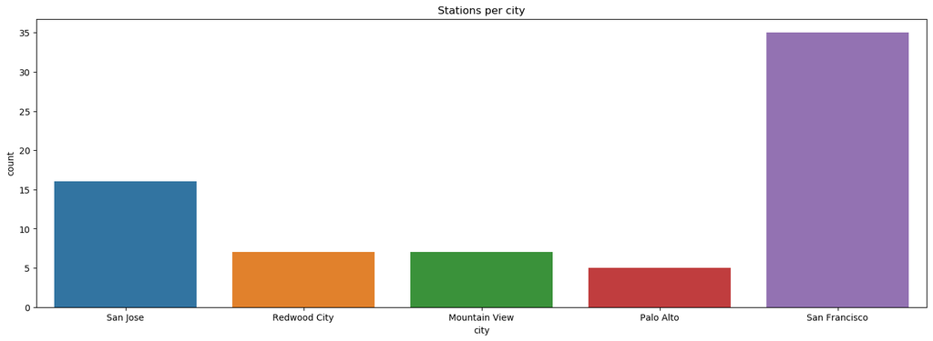

```python
sns.countplot(station_df.city)
plt.title('Stations per city')
```

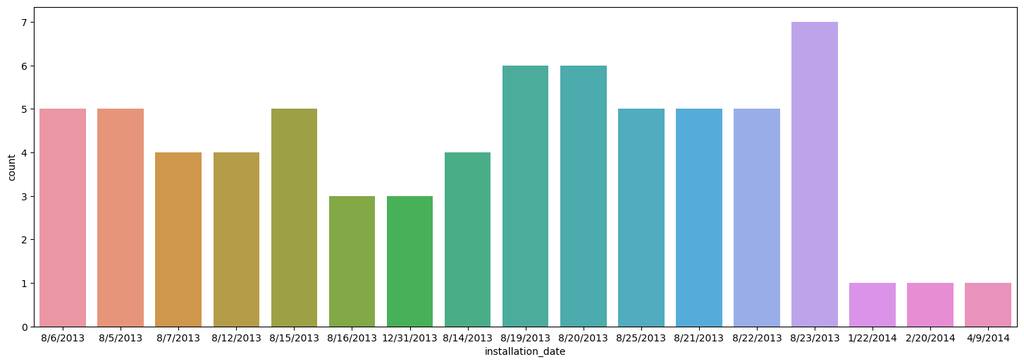

```python
sns.countplot(station_df.installation_date)
```

The bulk of the stations were installed in the latter half of 2013

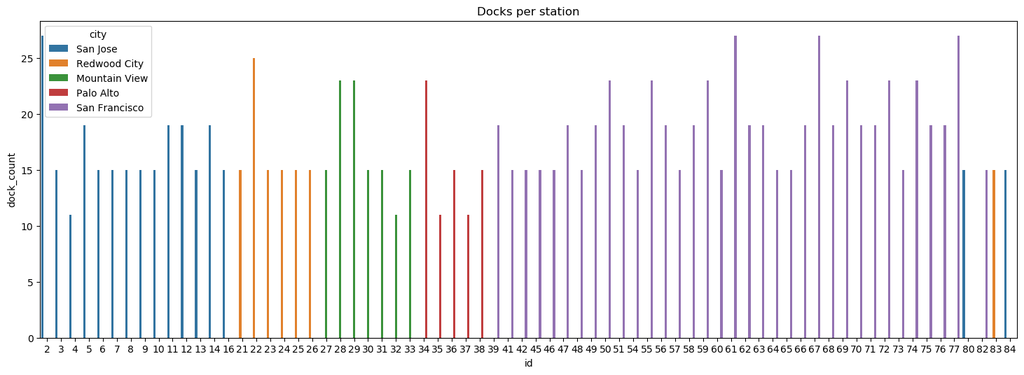

```python
sns.barplot('id','dock_count', data = station_df, hue = 'city')
plt.title('Docks per station')
```

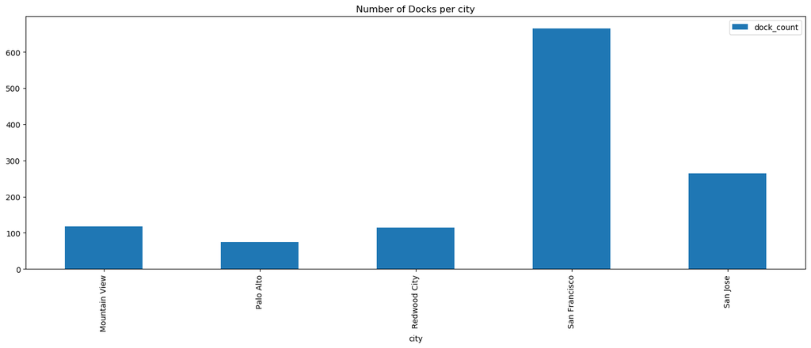

```python
# Aggregating the dock counts to see how many docks are in each city
station_df[['city','dock_count']].groupby('city').agg('sum').plot(kind='bar')
plt.title('Number of Docks per city')
```

San Francisco has the greatest number of docks

### Trips

```python
# Split out datetime in seperate components
trip_df['start_date'] = pd.to_datetime(trip_df['start_date'])
trip_df['end_date'] = pd.to_datetime(trip_df['end_date'])
trip_df['start_day'] = trip_df['start_date'].dt.date
trip_df['start_hour'] = trip_df['start_date'].dt.hour
trip_df['start_dayofweek'] = trip_df['start_date'].dt.dayofweek
trip_df['end_dayofweek'] = trip_df['end_date'].dt.dayofweek

trip_df['weekday'] = (trip_df['start_dayofweek'] < 5).astype(int) # flag to seperate weekdays and weekends
```

```python
trip_df['duration_min'] = (trip_df['duration']/60).astype('int64')  # duration is in seconds so convert to minutes
trip_df['duration_hours'] = (trip_df['duration']/3600).astype('int64')
```

```python
trip_df.describe().T
```

|  | count | mean | std | min | 25% | 50% | 75% | max |
| --- | --- | --- | --- | --- | --- | --- | --- | --- |
| id | 669959.0 | 460382.009899 | 264584.458487 | 4069.0 | 231082.5 | 459274.0 | 692601.0 | 913460.0 |
| duration | 669959.0 | 1107.949846 | 22255.437020 | 60.0 | 344.0 | 517.0 | 755.0 | 17270400.0 |
| start_station_id | 669959.0 | 57.851876 | 17.112474 | 2.0 | 50.0 | 62.0 | 70.0 | 84.0 |
| end_station_id | 669959.0 | 57.837438 | 17.200142 | 2.0 | 50.0 | 62.0 | 70.0 | 84.0 |
| bike_id | 669959.0 | 427.587620 | 153.450988 | 9.0 | 334.0 | 440.0 | 546.0 | 878.0 |
| start_hour | 669959.0 | 13.096118 | 4.554510 | 0.0 | 9.0 | 13.0 | 17.0 | 23.0 |
| start_dayofweek | 669959.0 | 2.405585 | 1.748998 | 0.0 | 1.0 | 2.0 | 4.0 | 6.0 |
| end_dayofweek | 669959.0 | 2.405408 | 1.749532 | 0.0 | 1.0 | 2.0 | 4.0 | 6.0 |
| weekday | 669959.0 | 0.875849 | 0.329754 | 0.0 | 1.0 | 1.0 | 1.0 | 1.0 |
| duration_min | 669959.0 | 17.973842 | 370.924710 | 1.0 | 5.0 | 8.0 | 12.0 | 287840.0 |
| duration_hours | 669959.0 | 0.132642 | 6.174362 | 0.0 | 0.0 | 0.0 | 0.0 | 4797.0 |

#### Subscriber vs Customer trips

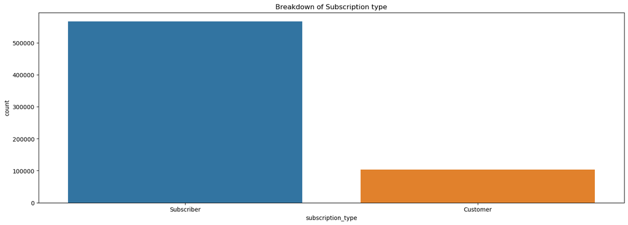

```python
sns.countplot(trip_df.subscription_type)
plt.title('Breakdown of Subscription type')
```

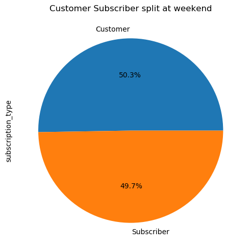

```python
trip_df[trip_df.weekday==0].subscription_type.value_counts().plot(kind='pie', autopct='%1.1f%%')
plt.title('Customer Subscriber split at weekend')
```

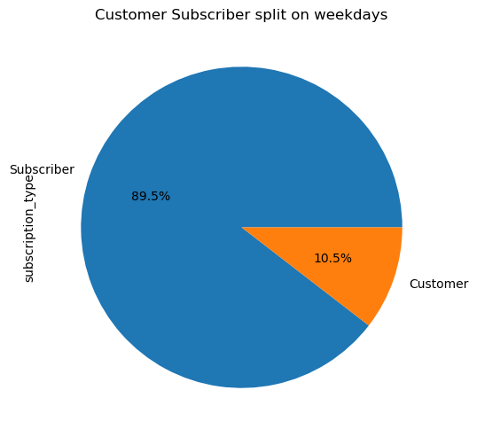

```python
trip_df[trip_df.weekday==1].subscription_type.value_counts().plot(kind='pie', autopct='%1.1f%%')

plt.title('Customer Subscriber split on weekdays')
```

Customers are more likely to use the ride share service during the weekend than on the weekdays. This could suggest that customers are using the service for leisure at the weekend and subscribers are using the service for commuting on the weekdays.

#### Starting and ending trips

```
0.9642052722629295
```

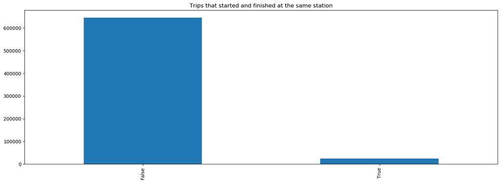

```python
# do people finish trips in the same location or a different one?
trip_df['same_station'] =  trip_df['start_station_id'] == trip_df['end_station_id']
trip_df['same_station'].value_counts().plot(kind='bar')
print(trip_df['same_station'].value_counts().values[0]/trip_df['same_station'].value_counts().values.sum())
plt.title('Trips that started and finished at the same station')
```

```python
station_locations = dict(zip(station_df.id, station_df.city))
```

```python
trip_df['start_city'] = trip_df['start_station_id'].map(station_locations)
trip_df['end_city'] = trip_df['end_station_id'].map(station_locations)
```

```
0.9984446809431622
```

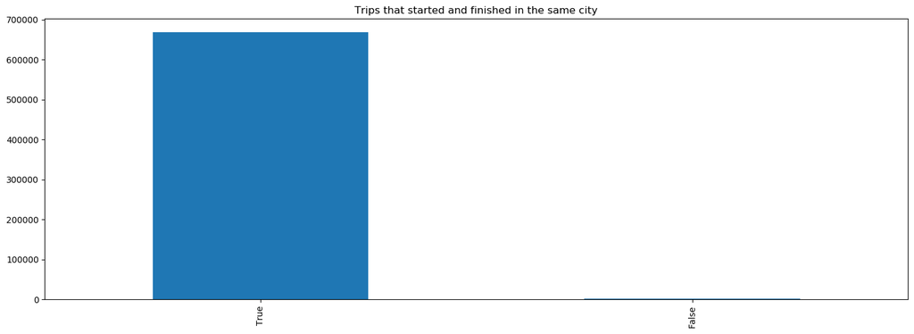

```python
trip_df['same_city'] =  trip_df['start_city'] == trip_df['end_city']
trip_df['same_city'].value_counts().plot(kind='bar')
plt.title('Trips that started and finished in the same city')
print(trip_df['same_city'].value_counts().values[0]/trip_df['same_city'].value_counts().values.sum())
```

```
0.9984446809431622
```

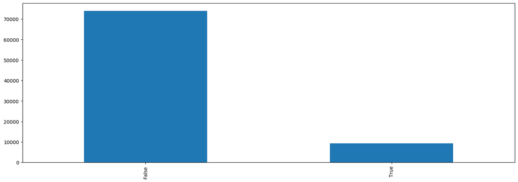

```python
trip_df[trip_df.weekday==0].same_station.value_counts().plot(kind='bar')
print(trip_df['same_city'].value_counts().values[0]/trip_df['same_city'].value_counts().values.sum())
```

```python
print("Inter city trips:")
print('==================')
print("Starting locations")
print(trip_df[~trip_df['same_city']].start_city.value_counts())
print("Ending locations")
print(trip_df[~trip_df['same_city']].end_city.value_counts())
```

```
Inter city trips:
==================
Starting locations
Palo Alto        480
Mountain View    421
Redwood City     104
San Jose          22
San Francisco     15
Name: start_city, dtype: int64
Ending locations
Palo Alto        498
Mountain View    439
Redwood City      61
San Francisco     25
San Jose          19
Name: end_city, dtype: int64
```

Most trips (96%) end in a differnt station than they began in. Most trips (99%) start and end in the same city. Of those trips that start and end in a different city the majority are between Palo Alto and Mountain View.

#### What are the most frequent stations to start and finish a trip in?

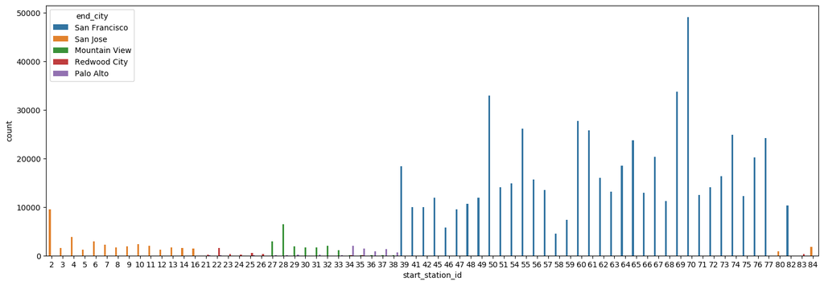

```python
sns.countplot('start_station_id', hue = 'end_city', data = trip_df)
```

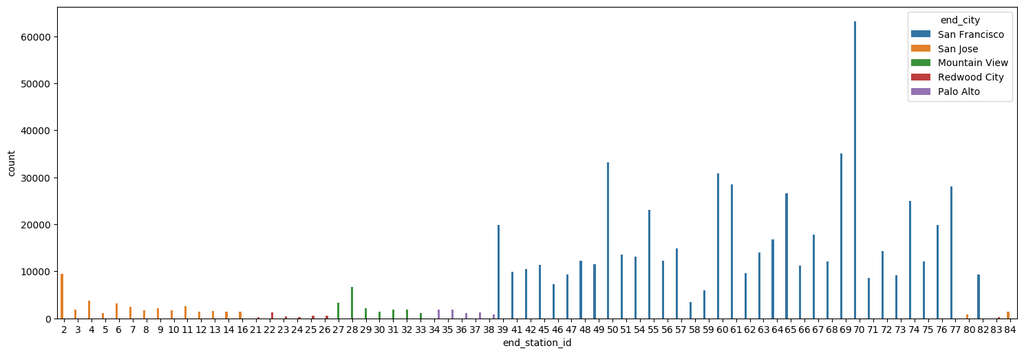

```python
sns.countplot('end_station_id',hue='end_city', data = trip_df)
```

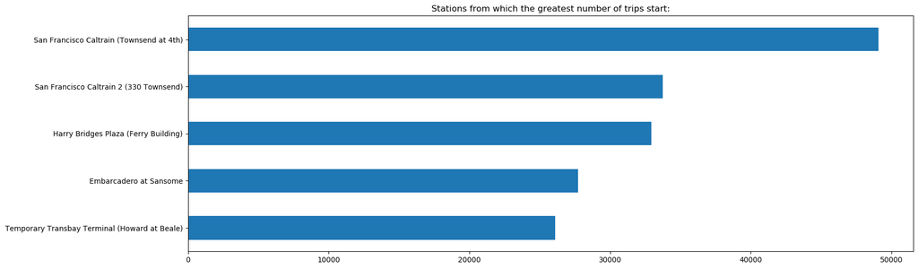

```python
trip_df.start_station_name.value_counts()[0:5].plot(kind='barh')
plt.gca().invert_yaxis()
plt.title('Stations from which the greatest number of trips start:')
```

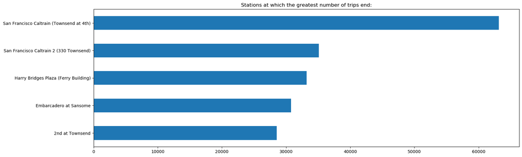

```python
trip_df.end_station_name.value_counts()[0:5].plot(kind='barh')
plt.gca().invert_yaxis()
plt.title('Stations at which the greatest number of trips end:')
```

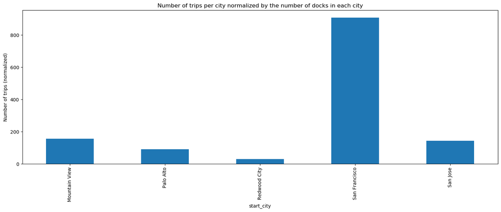

```python
# what are the number of trips per city taking into account the number of docks in each city?
normalized_trips = trip_df.groupby('start_city').size()
normalized_trips = normalized_trips / station_df[['city','dock_count']].groupby('city').sum().dock_count
normalized_trips.plot.bar()
plt.title('Number of trips per city normalized by the number of docks in each city')
plt.ylabel('Number of trips (normalized)')
```

More trips take place in San Francisco even when taking into account the greater number of docks/stations that are based in this city

#### Distribution of trips over time

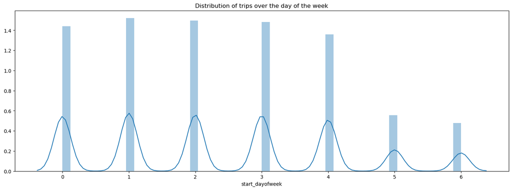

```python
sns.distplot(trip_df['start_dayofweek'])
plt.title('Distribution of trips over the day of the week')
```

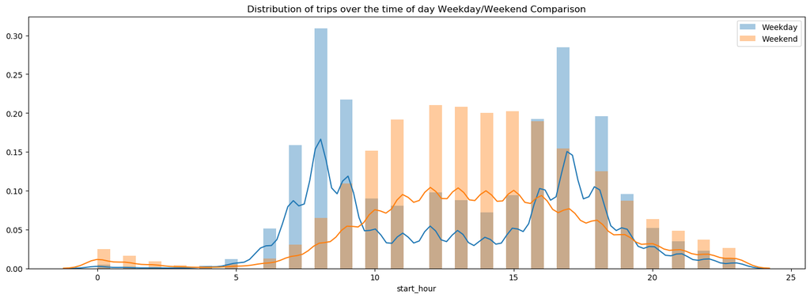

```python
# let's look at the distribution of time on a weekday vs weekend
plt.title('Distribution of trips over the time of day Weekday/Weekend Comparison')
sns.distplot(trip_df[trip_df.weekday==1]['start_hour'])
sns.distplot(trip_df[trip_df.weekday==0]['start_hour'])
plt.legend(labels = ['Weekday', 'Weekend'])
```

[figure not shown]

```python
sns.distplot(trip_df[(trip_df.subscription_type=='Subscriber')]['start_hour'])

sns.distplot(trip_df[(trip_df.subscription_type=='Customer')]['start_hour'])
plt.legend(labels = ['Subscriber','Subscriber'])
plt.title('Comparing distribution of trips over time for Customer and Subscriber')
```

Volume of trips drops at the weekend. There is also a different distribution of trips over start hour for weekdays vs weekends so it is worthwhile looking at these classes seperately in analysis.

These plots support the hypothesis that the bulk of the patrons are using the service for commuting purposes, with increased patronage during the week and at peak commuting hours for the typical 9-5 job.

The distributions of weekday vs weekend and subscriber vs customer look similar which is reasonable given the class distribution seen earlier.

#### Trip duration

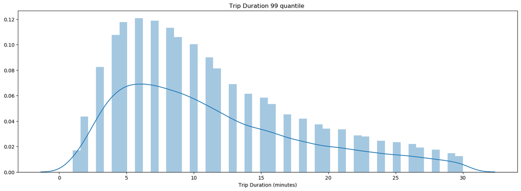

```python
sns.distplot(trip_df[(trip_df.weekday==0) & (trip_df.duration_min< trip_df.duration_min.quantile(0.95))]['duration_min'])
plt.title('Trip Duration 99 quantile ')
plt.xlabel('Trip Duration (minutes)')
```

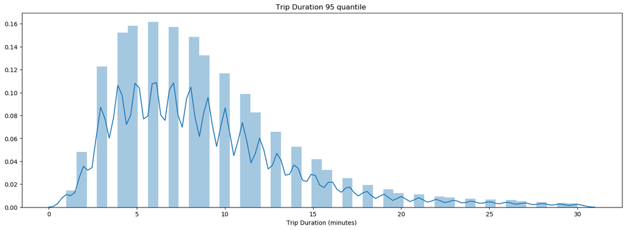

```python
sns.distplot(trip_df[(trip_df.duration_min< trip_df.duration_min.quantile(0.95))]['duration_min'])
plt.title('Trip Duration 95 quantile ')
plt.xlabel('Trip Duration (minutes)')
```

```python
trip_df[(trip_df.weekday==1)&(trip_df.duration_min< trip_df.duration_min.quantile(0.99))]['duration_min'].describe()
```

```
count    582986.000000
mean         10.378199
std          14.582709
min           1.000000
25%           5.000000
50%           8.000000
75%          11.000000
max         215.000000
Name: duration_min, dtype: float64
```

```python
trip_df[(trip_df.weekday==0)&(trip_df.duration_min< trip_df.duration_min.quantile(0.99))]['duration_min'].describe()
```

```
count    80272.000000
mean        22.144135
std         32.312165
min          1.000000
25%          7.000000
50%         11.000000
75%         21.000000
max        215.000000
Name: duration_min, dtype: float64
```

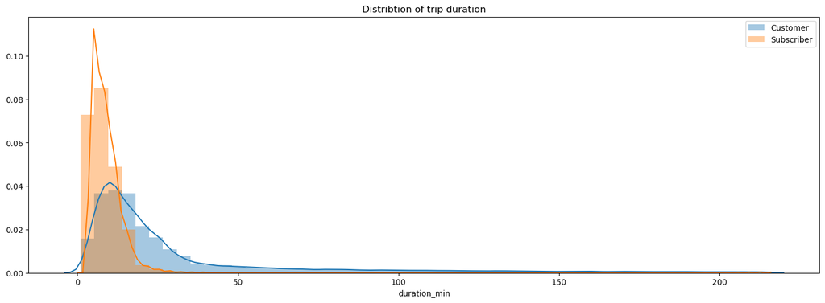

```python
sns.distplot(trip_df[(trip_df.subscription_type=='Customer')&(trip_df.duration_min< trip_df.duration_min.quantile(0.99))].duration_min)
sns.distplot(trip_df[(trip_df.subscription_type=='Subscriber')&(trip_df.duration_min< trip_df.duration_min.quantile(0.99))].duration_min)
plt.legend(labels = ['Customer','Subscriber'])
plt.title('Distribtion of trip duration')
```

95% of the trips last less than 30 minutes. 90% of the trips last less than 20 minutes. On average trips taken at the weekend last longer than trips taken during the week. Customer trips tended to last longer than subscriber trips

#### Number of trips per day over a year

```python
# aggregate the trips for each date
trips_per_day = {}

for date in trip_df.start_day:
    if date in trips_per_day:
        trips_per_day[date] += 1
    else:
        trips_per_day[date] = 1
```

```python
tripspd_df = pd.DataFrame(trips_per_day.items(), columns = ['date', 'num_trips'])
tripspd_df = tripspd_df.sort_values('date')
```

```python
# Digging into a year's worth of trip data
tripspd_2014 = tripspd_df[(tripspd_df.date > pd.Timestamp(2014,1,1)) & (tripspd_df.date < pd.Timestamp(2014,12,31))]
```

```python
tripspd_2014.date = pd.to_datetime(tripspd_df.date)
tripspd_2014['dayofweek'] = tripspd_2014['date'].dt.dayofweek
tripspd_2014['weekday'] = (tripspd_2014['dayofweek']<5).astype(int)
```

[output not shown]

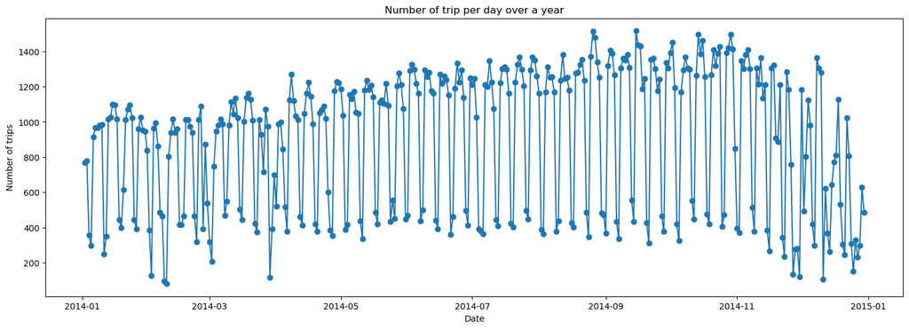

```python
plt.plot('date', 'num_trips', marker='o', data = tripspd_2014)
plt.title('Number of trip per day over a year')
plt.xlabel('Date')
plt.ylabel('Number of trips')
```

A cyclical pattern is evident in the time series data. This is weekly pattern of increased volume at the week and decreased volume at the weekend.

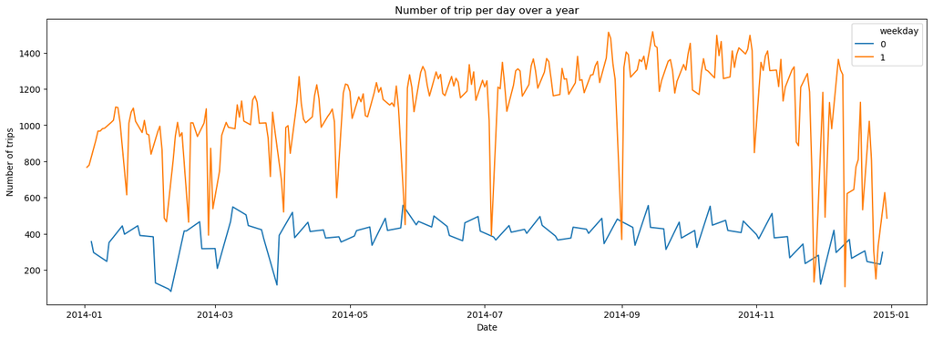

```python
sns.lineplot('date', 'num_trips',hue = 'weekday', data = tripspd_2014)
plt.title('Number of trip per day over a year')
plt.xlabel('Date')
plt.ylabel('Number of trips')
```

To verify the weekly cycle seen above, the data is split into its two classes and plotted as two series. The weekday (orange) time series has a higher baseline than the weekend series (blue). There are several troughs in the weekday series where the number of trips is lower than usual. This could be due to public holidays in the US calendar where the number of commuters drops. Comparing this to the dates of holidays listed below, this seems to be a reasonable assumption.

California Public holidays

- New Year's Day Wed 1 Jan 2014
- Martin Luther King Jr. Day Mon 20 Jan 2014
- Washington's Birthday Mon 17 Feb 2014
- Cesar Chavez Day Mon 31 Mar 2014
- Memorial Day Mon 26 May 2014
- Independence Day Fri 4 Jul 2014
- Labor Day Mon 1 Sep 2014
- California Admission Day Tue 9 Sep 2014
- Native American Day Fri 26 Sep 2014
- Veterans Day Tue 11 Nov 2014
- Thanksgiving Thu 27 Nov 2014
- Christmas Day Thu 25 Dec 2014

#### Comparing volume of trips per day over three years

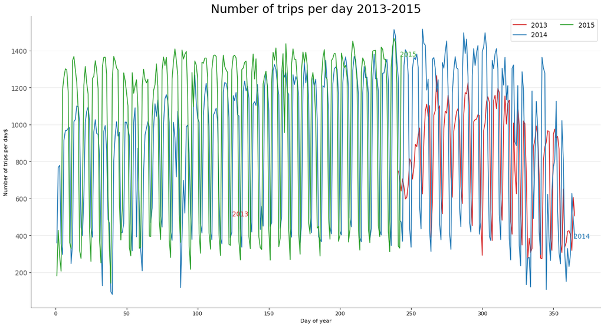

```python
# Import Data
df = tripspd_df
# Prepare data
df.date = pd.to_datetime(df.date)
df['year'] = [d.year for d in df.date]
df['month'] = [d.month for d in df.date]
df['day'] = [d.dayofyear for d in df.date]

years = df['year'].unique()
months = df['month'].unique()
# Draw Plot
mycolors = ['tab:red', 'tab:blue', 'tab:green']
plt.figure(figsize=(19,10), dpi= 80)

for i, y in enumerate(years):
    plt.plot('day', 'num_trips', data=df.loc[df.year==y, :], color=mycolors[i], label=y)
    plt.text(df.loc[df.year==y, :].shape[0]-.9, df.loc[df.year==y, 'num_trips'][-1:].values[0], y, fontsize=12, color=mycolors[i])

# Decoration
plt.ylabel('Number of trips per day$')
plt.yticks(fontsize=12, alpha=.7)
plt.title("Number of trips per day 2013-2015", fontsize=22)
plt.grid(axis='y', alpha=.3)
plt.xlabel('Day of year')

# Remove borders
plt.gca().spines["top"].set_alpha(0.0)
plt.gca().spines["bottom"].set_alpha(0.5)
plt.gca().spines["right"].set_alpha(0.0)
plt.gca().spines["left"].set_alpha(0.5)
plt.legend(loc='upper right', ncol=2, fontsize=12)
plt.show()
```

The increasing number of trips over the approx. 2 year period can be seen.

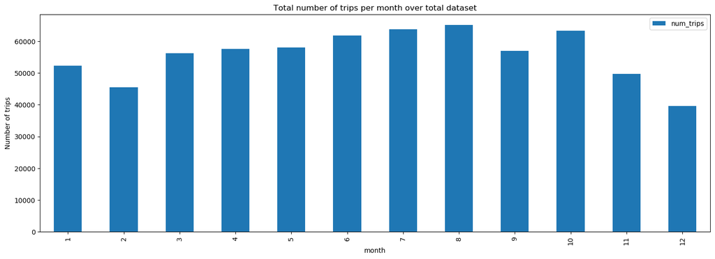

```python
tripspd_df[['month', 'num_trips']].groupby('month').sum().plot(kind='bar')
plt.title('Total number of trips per month over total dataset')
plt.ylabel('Number of trips')
```

There is a slight increase in the number of trips mid year. This could be in connection with warmer summer months and better weather, however, the dataset does not have complete data for the end of 2015. In late 2013, the service was just being established so it is likely that late 2015 would have more trips that late 2013, judging on the increasing trend in the volume of trips over the full dataset. This is a potential explanation for the lower number of trips in the fourth quarter of the year. More data is needed to identify whether there is a pattern here.

#### Route

```python
trip_df['route'] = list(zip(trip_df.start_station_id, trip_df.end_station_id))
```

```python
print('Top ten routes (start_station_id, end_station_id) during week:')
print(trip_df[trip_df.weekday==1]['route'].value_counts()[0:10])
print('Top ten routes (start_station_id, end_station_id) during weekend:')
print(trip_df[trip_df.weekday==0]['route'].value_counts()[0:10])
```

```
Top ten routes (start_station_id, end_station_id) during week:
(69, 65)    5851
(65, 70)    4718
(50, 60)    4614
(61, 50)    4424
(60, 74)    3958
(50, 61)    3956
(51, 70)    3849
(74, 61)    3739
(64, 77)    3531
(55, 70)    3503
Name: route, dtype: int64
Top ten routes (start_station_id, end_station_id) during weekend:
(50, 60)    1550
(60, 50)     907
(60, 60)     873
(50, 50)     841
(54, 60)     483
(54, 50)     459
(48, 60)     451
(35, 35)     448
(61, 50)     415
(39, 67)     412
Name: route, dtype: int64
```

#### Ride Distance

```python
station_df['coords'] = station_df[['lat','long']].values.tolist()
```

```python
station_coords = dict(zip(station_df.id, station_df.coords))
```

```python
trip_df['start_coords'] = trip_df.start_station_id.map(station_coords)
```

```python
trip_df['end_coords'] = trip_df.end_station_id.map(station_coords)
```

```python
# Using the geopy library to calculate the  distance between two points

trip_df['distance'] = trip_df.apply(lambda row: geopy.distance.distance(row.start_coords, row.end_coords).km, axis=1)
```

```
count    669959.000000
mean          1.333441
std           0.792324
min           0.000000
25%           0.865146
50%           1.309982
75%           1.695437
max          68.057907
Name: distance, dtype: float64
```

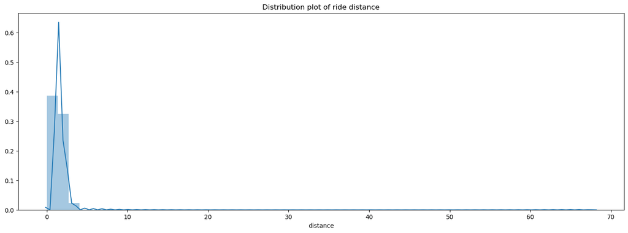

```python
print(trip_df['distance'].describe())
sns.distplot(trip_df['distance'])
plt.title('Distribution plot of ride distance')
```

```python
trip_df['distance'].describe()
```

```
count    669959.000000
mean          1.333441
std           0.792324
min           0.000000
25%           0.865146
50%           1.309982
75%           1.695437
max          68.057907
Name: distance, dtype: float64
```

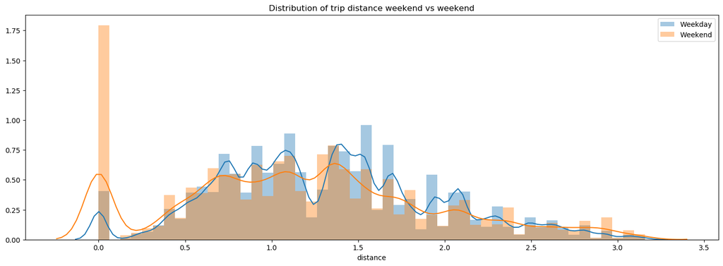

```python
sns.distplot(trip_df[(trip_df.weekday==1)&(trip_df.distance< trip_df.distance.quantile(0.99))]['distance'])
sns.distplot(trip_df[(trip_df.weekday==0)&(trip_df.distance< trip_df.distance.quantile(0.99))]['distance'])

plt.title('Distribution of trip distance weekend vs weekend')
plt.legend(labels = ['Weekday','Weekend'])
```

Note that the peak around zero is due to the inability to calcuate ride distance for trips starting and ending at the same station; net distance of the trip is zero. 99% of trips are under 3.5 km. The average ride distance is 1.33km